# Aula de laboratório - Escolha Qualitativa

Autor

Rafael Bressan

Data de Publicação

14 de novembro de 2024

```python
import numpy as np
import pandas as pd
import wooldridge as woo
import statsmodels.formula.api as smf
```

## Modelo de Probabilidade Linear

Vamos analizar participação na força de trabalho de mulheres casadas com os dados `mroz` do pacote `wooldridge`. Nossa variável dependente será o status de participação na força de trabalho, $inlf\in\{0, 1\}$.

Se uma variável *dummy* é usada como variável dependente, nós podemos usar MQO para estimar a relação desta com os regressores normalmente. A probabilidade condicional de ocorrência do evento é:

$$P(y=1|x)=E[y|x]=\beta_0 + \beta_1 x$$

A interpretação dos coeficientes é direta, um aumento de uma unidade em $x$ provoca um aumento médio na probabilidade do evento de $\beta_1$. Modelos MPL sofrem de heterocedasticidade e, portanto, devemos utilizar erros padrão robustos.

**Cheque a estrutura dos dados com uma tabela de estatísticas descritivas.**

*Prompt*

`crie uma tabela de estatísticas descritivas para todas as variáveis do conjunto de dados mroz utilizando a função datasummary do pacote modelsummary. As estatísticas devem ser número de observações, número de valores únicos, média e desvio padrão.`

**Código**

```python
mroz = woo.dataWoo("mroz")
stats = mroz.describe().transpose()[["count", "mean", "std"]]
# Get unique values
unique_values = mroz.nunique()
unique_values.name = "NUnique"
df = stats.join(unique_values)
df
```

|  | count | mean | std | NUnique |
| --- | --- | --- | --- | --- |
| inlf | 753.0 | 0.568393 | 0.495630 | 2 |
| hours | 753.0 | 740.576361 | 871.314216 | 306 |
| kidslt6 | 753.0 | 0.237716 | 0.523959 | 4 |
| kidsge6 | 753.0 | 1.353254 | 1.319874 | 9 |
| age | 753.0 | 42.537849 | 8.072574 | 31 |
| educ | 753.0 | 12.286853 | 2.280246 | 13 |
| wage | 428.0 | 4.177682 | 3.310282 | 373 |
| repwage | 753.0 | 1.849734 | 2.419887 | 164 |
| hushrs | 753.0 | 2267.270916 | 595.566649 | 422 |
| husage | 753.0 | 45.120850 | 8.058793 | 31 |
| huseduc | 753.0 | 12.491368 | 3.020804 | 15 |
| huswage | 753.0 | 7.482179 | 4.230559 | 697 |
| faminc | 753.0 | 23080.594954 | 12190.202026 | 613 |
| mtr | 753.0 | 0.678863 | 0.083496 | 22 |
| motheduc | 753.0 | 9.250996 | 3.367468 | 9 |
| fatheduc | 753.0 | 8.808765 | 3.572290 | 9 |
| unem | 753.0 | 8.623506 | 3.114934 | 7 |
| city | 753.0 | 0.642762 | 0.479504 | 2 |
| exper | 753.0 | 10.630810 | 8.069130 | 40 |
| nwifeinc | 753.0 | 20.128964 | 11.634797 | 706 |
| lwage | 428.0 | 1.190173 | 0.723198 | 373 |
| expersq | 753.0 | 178.038513 | 249.630849 | 40 |

**Agora faça a regressão da *dummy* de presença na força de trabalho em relação as seguintes variáveis: nwifeinc, educ, exper, exper^2, age, kidslt6, kidsge6.**

*Prompt*

`faça uma regressão linear da variável inlf em relação as variáveis nwifeinc, educ, exper, exper^2, age, kidslt6, kidsge6. Os erros padrão reportados devem ser robustos. Utilize o pacote fixest.`

**Código**

```python
fml = "inlf ~ nwifeinc + educ + exper + I(exper**2) + age + kidslt6 + kidsge6"
mpl = smf.ols(fml, data=mroz).fit(cov_type="HC1")
mpl.summary()
```

OLS Regression Results

| Dep. Variable: | inlf | R-squared: | 0.264 |
| --- | --- | --- | --- |
| Model: | OLS | Adj. R-squared: | 0.257 |
| Method: | Least Squares | F-statistic: | 62.48 |
| Date: | Tue, 30 Jul 2024 | Prob (F-statistic): | 1.30e-70 |
| Time: | 11:19:04 | Log-Likelihood: | -423.89 |
| No. Observations: | 753 | AIC: | 863.8 |
| Df Residuals: | 745 | BIC: | 900.8 |
| Df Model: | 7 |  |  |
| Covariance Type: | HC1 |  |  |

|  | coef | std err | z | P>\|z\| | [0.025 | 0.975] |
| --- | --- | --- | --- | --- | --- | --- |
| Intercept | 0.5855 | 0.152 | 3.846 | 0.000 | 0.287 | 0.884 |
| nwifeinc | -0.0034 | 0.002 | -2.233 | 0.026 | -0.006 | -0.000 |
| educ | 0.0380 | 0.007 | 5.229 | 0.000 | 0.024 | 0.052 |
| exper | 0.0395 | 0.006 | 6.797 | 0.000 | 0.028 | 0.051 |
| I(exper ** 2) | -0.0006 | 0.000 | -3.138 | 0.002 | -0.001 | -0.000 |
| age | -0.0161 | 0.002 | -6.707 | 0.000 | -0.021 | -0.011 |
| kidslt6 | -0.2618 | 0.032 | -8.237 | 0.000 | -0.324 | -0.200 |
| kidsge6 | 0.0130 | 0.014 | 0.962 | 0.336 | -0.014 | 0.040 |

| Omnibus: | 169.137 | Durbin-Watson: | 0.494 |
| --- | --- | --- | --- |
| Prob(Omnibus): | 0.000 | Jarque-Bera (JB): | 36.741 |
| Skew: | -0.196 | Prob(JB): | 1.05e-08 |
| Kurtosis: | 1.991 | Cond. No. | 3.06e+03 |

Notes:  
[1] Standard Errors are heteroscedasticity robust (HC1)  
[2] The condition number is large, 3.06e+03. This might indicate that there are  
strong multicollinearity or other numerical problems.

Por construção, um modelo MPL pode render previsão de probabilidade fora do intervalo $\left[0,1\right]$ para uma certa combinação de regressores (que pode ser realista ou não).

Como exemplo, supomos duas mulheres, a primeira com 20 anos, sem experiência, 5 anos de educação, 2 crianças com menos de 6 anos e renda de $ 100 (em milhares). A segunda mulher possui 52 anos, 30 anos de experiência e 17 de educação, sem crianças e renda.

**Faça a previsão de probabilidade de estarem no mercado de trabalho para ambas hipotéticas mulheres.**

*Prompt*

`com base na regressão anterior, faça a previsão de probabilidade de estarem no mercado de trabalho para duas mulheres hipotéticas. A primeira com 20 anos, sem experiência, 5 anos de educação, 2 crianças com menos de 6 anos e renda de $ 100 (em milhares). A segunda mulher possui 52 anos, 30 anos de experiência e 17 de educação, sem crianças e renda.`

```python
xpred = pd.DataFrame({
    "nwifeinc": [100, 0],
    "educ": [5, 17],
    "exper": [0, 30],
    "age": [20, 52],
    "kidslt6": [2, 0],
    "kidsge6": [0, 0]
})
mpl.predict(xpred)
```

```
0   -0.410458
1    1.042808
dtype: float64
```

## Modelos Logit e Probit

Estes são modelos especializados em variáveis dependentes binárias e, portanto, não sofrem do problema de predição de probabilidade fora do intervalo $\left[0,1\right]$. A um indexador linear, estes modelos aplicam uma função (não-linear) que garante $y\in \left[0,1\right]$. Esta é chamada de função de ligação.

- no modelo **probit** a função link é $G(z)=\Phi(z)$, a função de distribuição da Normal, e;
- no modelo **logit** a função link é $G(z)=\Lambda(z)=\frac{\exp(z)}{1+\exp(z)}$, a função de distribuição Logística.

Desta forma, a probabilidade do evento é definida como:

$$P(y=1|x)=G(\beta_0 + \beta_1 x)$$

No `Python` estimamos esses modelos através da função `glm`, de *Generalized Linear Models*, especificando o argumento `family`. OU, através das funções específicas, `probit` e `logit`. Vejamos um exemplo.

```python
# Extract parameters
def extract_parameters(models, model_names):
    param_dict = {}
    for model in models:
        params = model.params
        std_errors = model.bse
        parameters = []
        for param, std_error in zip(params, std_errors):
            parameters.append(f"{param:.4f}")
            parameters.append(f"({std_error:.4f})")

        param_dict[model_names.pop(0)] = parameters

    df_index = []
    for i in models[0].params.index:
        df_index.append(i)
        df_index.append("")

    df = pd.DataFrame(param_dict, index=df_index)
    return df


logit = smf.logit(fml, data=mroz).fit()
probit = smf.probit(fml, data=mroz).fit()

extract_parameters([logit, probit], ["Logit", "Probit"])
```

```
Optimization terminated successfully.
         Current function value: 0.533553
         Iterations 6
Optimization terminated successfully.
         Current function value: 0.532938
         Iterations 5
```

|  | Logit | Probit |
| --- | --- | --- |
| Intercept | 0.4255 | 0.2701 |
|  | (0.8604) | (0.5086) |
| nwifeinc | -0.0213 | -0.0120 |
|  | (0.0084) | (0.0048) |
| educ | 0.2212 | 0.1309 |
|  | (0.0434) | (0.0253) |
| exper | 0.2059 | 0.1233 |
|  | (0.0321) | (0.0187) |
| I(exper ** 2) | -0.0032 | -0.0019 |
|  | (0.0010) | (0.0006) |
| age | -0.0880 | -0.0529 |
|  | (0.0146) | (0.0085) |
| kidslt6 | -1.4434 | -0.8683 |
|  | (0.2036) | (0.1185) |
| kidsge6 | 0.0601 | 0.0360 |
|  | (0.0748) | (0.0435) |

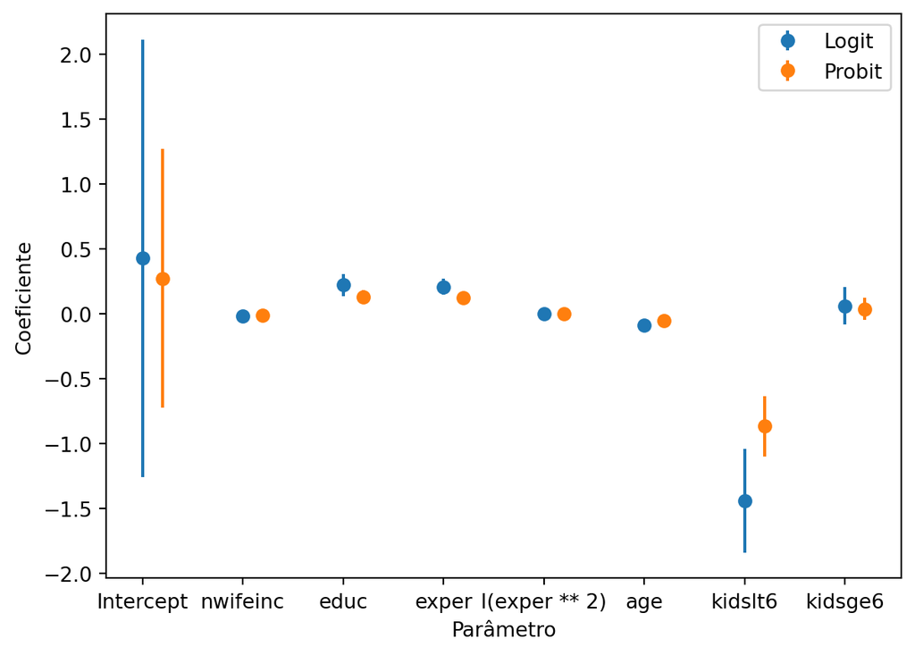

```python
import matplotlib.pyplot as plt

# Calculate the standard errors for logit and probit models
logit_ci = 1.96 * logit.bse
probit_ci = 1.96 * probit.bse

x_axis = np.array(range(len(logit.params)))
# Create the error bar plot
fig, ax = plt.subplots()
ax.errorbar(x_axis, logit.params, yerr=logit_ci, fmt="o", label="Logit")
ax.errorbar(x_axis + 0.2, probit.params, yerr=probit_ci, fmt="o", label="Probit")
# Hack the x-axis to show the parameter names
x_axis_labels = [" "] + logit.params.index.to_list()
ax.set_xticklabels(x_axis_labels)
ax.set_ylabel("Coeficiente")
ax.set_xlabel("Parâmetro")
ax.legend()
plt.show()
```

Podemos fazer a previsão da probabilidade das mesmas mulheres anteriores estarem no mercado de trabalho.

```python
pd.DataFrame({
    "Logit": logit.predict(xpred),
    "Probit": probit.predict(xpred)
})
```

|  | Logit | Probit |
| --- | --- | --- |
| 0 | 0.005218 | 0.001065 |
| 1 | 0.950049 | 0.959870 |

As previsões de logit e probit são semelhantes, mas especialmente nas caudas elas podem diferirem de forma significativa. O comando `predict` também pode retornar o valor do índice linear ($\hat\beta_0 + \hat\beta_1 x_i$) quando o argumento for `which = linear`.

```python
pd.DataFrame({
    "Logit": logit.predict(xpred, which="linear"),
    "Probit": probit.predict(xpred, which="linear")
})
```

|  | Logit | Probit |
| --- | --- | --- |
| 0 | -5.250409 | -3.071484 |
| 1 | 2.945474 | 1.749174 |

## Efeitos Parciais

Os parâmetros de modelos não-lineares como logit e probit não possuem uma interpretação direta dos efeitos *ceteris paribus* do regressor sobre a variável dependente. Uma medida utilizada é o efeito parcial (ou efeito marginal) que é dependente do ponto $x_i$ em que se faz a análise. Este efeito marginal é equivalente a inclinação da curva de resposta do modelo em um determinado ponto.

$$\begin{align}
\frac{\partial\hat y}{\partial x}&=\frac{\partial G(x\hat\beta)}{\partial x}\\
&=\hat\beta \cdot g(x\hat\beta)
\end{align}$$

Onde é possível verificar que o efeito marginal depende tanto do valor estimado $\hat\beta$ quanto do ponto onde se faz a análise, $x$. O fato de este efeito diferir por valor do regressor faz com que seja difícil apresentar os resultados de uma maneira concisa. Adota-se, em geral, duas medidas de efeito parcial:

- Efeito Parcial na Média (PEA): $PEA(X_j)=\beta_j\cdot g(\bar{x} \beta)$
- Efeito Parcial Médio (APE): $APE(X_j)=\beta_j\cdot\frac{1}{n} \sum_{i=1}^N g(x_i \beta)$

**Calcule manualmente o PEA do modelo logit**

```python
from scipy.stats import logistic

regressors = ["nwifeinc", "educ", "exper", "age", "kidslt6", "kidsge6"]
x_mean = mroz.loc[:, regressors].mean()
betas = logit.params
df = pd.concat([betas, x_mean], axis=1, keys=["betas", "x_mean"])
df.loc["I(exper ** 2)", "x_mean"] = (mroz["exper"] ** 2).mean()
df.loc["Intercept", "x_mean"] = 1
lin_index = (df["betas"] * df["x_mean"]).sum()
logit_pea = logistic.pdf(lin_index) * betas
print(f"PEA manual: \n{logit_pea}")
```

```
PEA manual:
Intercept        0.103448
nwifeinc        -0.005190
educ             0.053777
exper            0.050057
I(exper ** 2)   -0.000767
age             -0.021403
kidslt6         -0.350950
kidsge6          0.014616
dtype: float64
```

```python
# PEA using get_margeff
logit_margeff = logit.get_margeff(at="mean")
logit_margeff.summary()
```

Logit Marginal Effects

| Dep. Variable: | inlf |
| --- | --- |
| Method: | dydx |
| At: | mean |

|  | dy/dx | std err | z | P>\|z\| | [0.025 | 0.975] |
| --- | --- | --- | --- | --- | --- | --- |
| nwifeinc | -0.0052 | 0.002 | -2.534 | 0.011 | -0.009 | -0.001 |
| educ | 0.0538 | 0.011 | 5.092 | 0.000 | 0.033 | 0.074 |
| exper | 0.0501 | 0.008 | 6.397 | 0.000 | 0.035 | 0.065 |
| I(exper ** 2) | -0.0008 | 0.000 | -3.096 | 0.002 | -0.001 | -0.000 |
| age | -0.0214 | 0.004 | -6.046 | 0.000 | -0.028 | -0.014 |
| kidslt6 | -0.3509 | 0.050 | -7.070 | 0.000 | -0.448 | -0.254 |
| kidsge6 | 0.0146 | 0.018 | 0.804 | 0.422 | -0.021 | 0.050 |

**Calcule manualmente o APE do modelo logit**

```python
# Manualmente
pdf = logistic.pdf(logit.predict(which='linear'))
logit_ape = betas * pdf.mean()
print(f"APE manual: \n{logit_ape}")
```

```
APE manual:
Intercept        0.075977
nwifeinc        -0.003812
educ             0.039497
exper            0.036764
I(exper ** 2)   -0.000563
age             -0.015719
kidslt6         -0.257754
kidsge6          0.010735
dtype: float64
```

```python
# Usando get_margeff
logit_margeff = logit.get_margeff()
logit_margeff.summary()
```

Logit Marginal Effects

| Dep. Variable: | inlf |
| --- | --- |
| Method: | dydx |
| At: | overall |

|  | dy/dx | std err | z | P>\|z\| | [0.025 | 0.975] |
| --- | --- | --- | --- | --- | --- | --- |
| nwifeinc | -0.0038 | 0.001 | -2.571 | 0.010 | -0.007 | -0.001 |
| educ | 0.0395 | 0.007 | 5.414 | 0.000 | 0.025 | 0.054 |
| exper | 0.0368 | 0.005 | 7.139 | 0.000 | 0.027 | 0.047 |
| I(exper ** 2) | -0.0006 | 0.000 | -3.176 | 0.001 | -0.001 | -0.000 |
| age | -0.0157 | 0.002 | -6.603 | 0.000 | -0.020 | -0.011 |
| kidslt6 | -0.2578 | 0.032 | -8.070 | 0.000 | -0.320 | -0.195 |
| kidsge6 | 0.0107 | 0.013 | 0.805 | 0.421 | -0.015 | 0.037 |